# Appendix

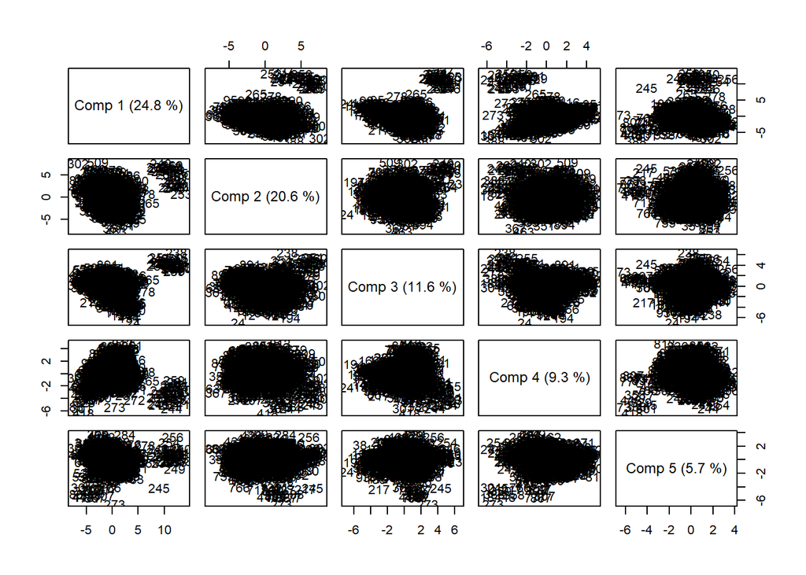

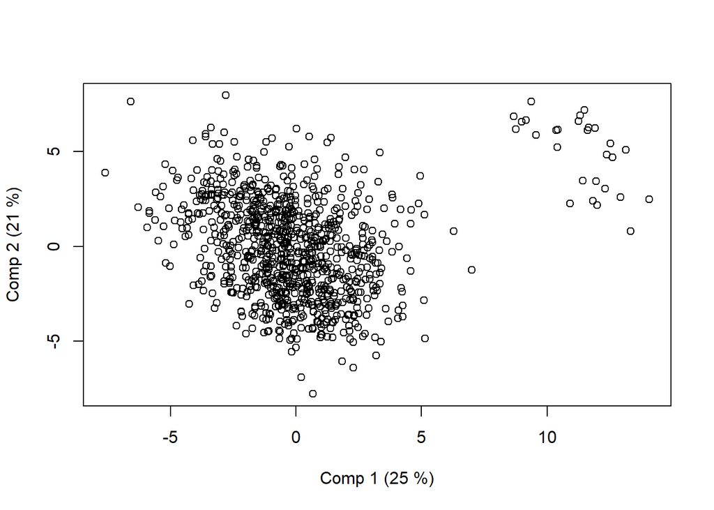

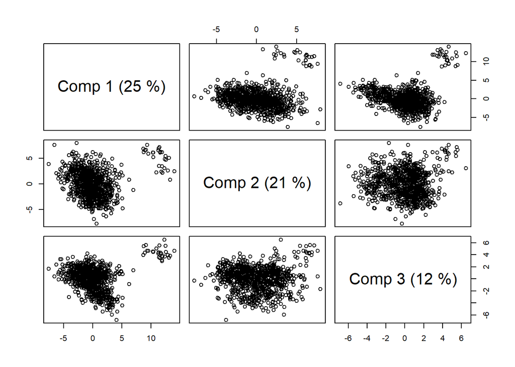

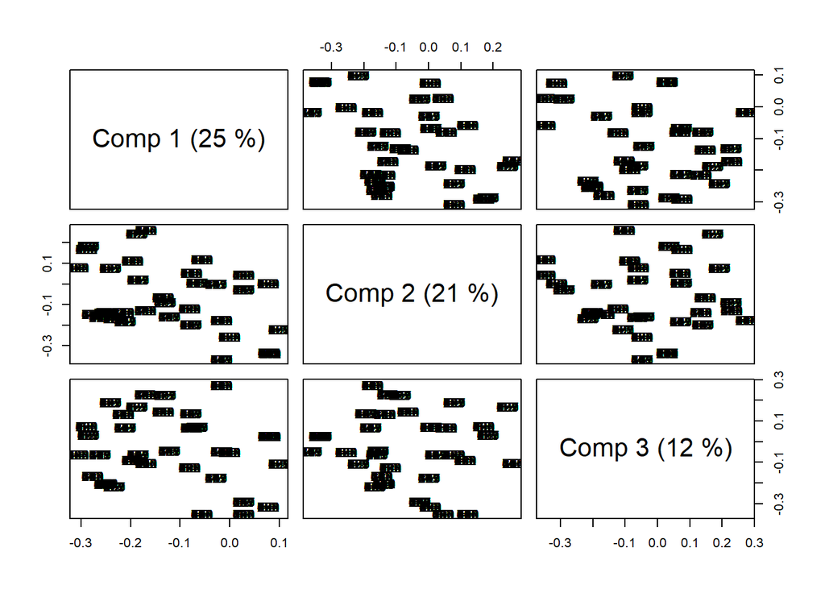

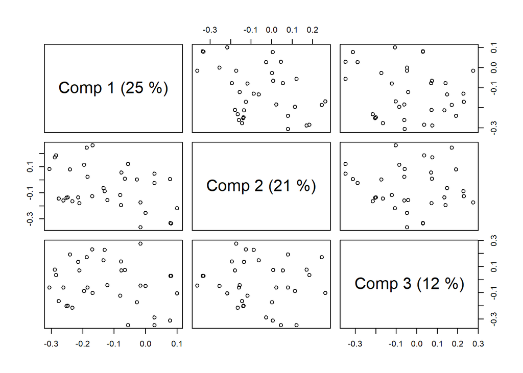

## Starting Pitcher

#### Statistics

```r
#starting_picther_salary <- readRDS("~/starting_pitcher_salary.RDS")
#describe(starting_pitcher_salary)
```

#### LM

```r
summary(spmodel)
```

```
##
## Call:
## lm(formula = salary ~ ., data = starting_pitcher_salary)
##
## Residuals:
##       Min        1Q    Median        3Q       Max
## -12878993   -923664         0    907972  18203730
##
## Coefficients:
##                     Estimate Std. Error t value Pr(>|t|)
## (Intercept)       -1.599e+09  4.082e+07 -39.165  < 2e-16 ***
## playerIDabbotky01 -2.094e+06  2.941e+06  -0.712 0.476510
## playerIDabbotpa01 -5.310e+06  2.255e+06  -2.355 0.018598 *
## playerIDacevejo01 -9.076e+06  2.950e+06  -3.076 0.002120 **
## playerIDackerji01  2.248e+06  3.114e+06   0.722 0.470337
## playerIDadamste01 -5.282e+06  2.263e+06  -2.334 0.019670 *
## playerIDaffelje01 -8.262e+06  2.962e+06  -2.789 0.005325 **
## playerIDaguilri01  3.341e+06  2.932e+06   1.139 0.254641
## playerIDalexado01  2.707e+06  1.978e+06   1.368 0.171383
## playerIDalvarhe01 -1.855e+07  2.326e+06  -7.972 2.40e-15 ***
## playerIDalvarwi01 -1.585e+06  1.587e+06  -0.999 0.317987
## playerIDanderal02  2.158e+06  1.983e+06   1.089 0.276441
## playerIDanderbr02 -4.298e+06  1.676e+06  -2.565 0.010375 *
## playerIDanderbr04 -1.141e+07  2.264e+06  -5.041 4.98e-07 ***
## playerIDanderch01 -1.971e+07  2.291e+06  -8.606  < 2e-16 ***
## playerIDanderji02 -7.072e+06  1.996e+06  -3.543 0.000403 ***
## playerIDandujjo01  5.788e+06  2.250e+06   2.573 0.010152 *
## playerIDankieri01 -6.789e+06  2.949e+06  -2.303 0.021387 *
## playerIDappieke01  9.274e+05  1.468e+06   0.632 0.527539
## playerIDaquinlu01  1.425e+06  2.269e+06   0.628 0.530105
## playerIDarchech01 -1.523e+07  2.112e+06  -7.212 7.38e-13 ***
## playerIDarmasto02 -7.830e+06  2.001e+06  -3.914 9.34e-05 ***
## playerIDarmstja01  7.973e+05  1.801e+06   0.443 0.658060
## playerIDarochre01 -1.676e+06  2.929e+06  -0.572 0.567171
## playerIDarrieja01 -1.652e+07  2.044e+06  -8.081 1.01e-15 ***
## playerIDarrojro01 -2.007e+06  2.324e+06  -0.864 0.387791
## playerIDarroybr01 -6.848e+06  1.528e+06  -4.482 7.74e-06 ***
## playerIDasencmi01 -7.451e+06  2.942e+06  -2.532 0.011393 *
## playerIDashbyan01 -1.131e+06  1.604e+06  -0.705 0.480735
## playerIDastacpe01 -2.928e+06  1.592e+06  -1.839 0.066080 .
```

[output cut: 899 more lines]

```
## BFP               -3.350e+03  4.523e+03  -0.741 0.458988
## GF                 2.773e+04  5.227e+04   0.531 0.595730
## R                 -4.257e+03  1.588e+04  -0.268 0.788722
## SH                -2.459e+04  2.188e+04  -1.124 0.261118
## SF                 2.210e+04  2.516e+04   0.879 0.379719
## GIDP               1.541e+04  1.456e+04   1.058 0.290154
## ERA_plus           1.543e+04  6.097e+03   2.531 0.011452 *
## APR                1.921e+06  2.401e+05   8.000 1.92e-15 ***
## ERA               -1.465e+05  4.598e+05  -0.319 0.750070
## ---
## Signif. codes:  0 '***' 0.001 '**' 0.01 '*' 0.05 '.' 0.1 ' ' 1
##
## Residual standard error: 2634000 on 2383 degrees of freedom
## Multiple R-squared:  0.7473, Adjusted R-squared:  0.6479
## F-statistic: 7.521 on 937 and 2383 DF,  p-value: < 2.2e-16
```

```r
round(summary(spmodel)$coefficients, 4)
```

```
##                        Estimate   Std. Error  t value Pr(>|t|)
## (Intercept)       -1.598675e+09 40818931.375 -39.1650   0.0000
## playerIDabbotky01 -2.094162e+06  2941074.107  -0.7120   0.4765
## playerIDabbotpa01 -5.310124e+06  2254724.070  -2.3551   0.0186
## playerIDacevejo01 -9.075800e+06  2950244.822  -3.0763   0.0021
## playerIDackerji01  2.248177e+06  3113617.661   0.7220   0.4703
## playerIDadamste01 -5.281667e+06  2262777.096  -2.3342   0.0197
## playerIDaffelje01 -8.262070e+06  2962101.703  -2.7893   0.0053
## playerIDaguilri01  3.341318e+06  2932461.945   1.1394   0.2546
## playerIDalexado01  2.706691e+06  1978306.241   1.3682   0.1714
## playerIDalvarhe01 -1.854548e+07  2326275.471  -7.9722   0.0000
## playerIDalvarwi01 -1.584691e+06  1586574.866  -0.9988   0.3180
## playerIDanderal02  2.158427e+06  1982756.663   1.0886   0.2764
## playerIDanderbr02 -4.297897e+06  1675522.424  -2.5651   0.0104
## playerIDanderbr04 -1.141425e+07  2264336.041  -5.0409   0.0000
## playerIDanderch01 -1.971236e+07  2290567.153  -8.6059   0.0000
## playerIDanderji02 -7.072222e+06  1995946.668  -3.5433   0.0004
## playerIDandujjo01  5.787749e+06  2249706.598   2.5727   0.0102
## playerIDankieri01 -6.789482e+06  2948619.495  -2.3026   0.0214
## playerIDappieke01  9.274114e+05  1467748.165   0.6319   0.5275
## playerIDaquinlu01  1.424920e+06  2269208.551   0.6279   0.5301
## playerIDarchech01 -1.523015e+07  2111849.655  -7.2118   0.0000
## playerIDarmasto02 -7.830070e+06  2000627.371  -3.9138   0.0001
## playerIDarmstja01  7.972521e+05  1801091.618   0.4426   0.6581
## playerIDarochre01 -1.676082e+06  2928666.002  -0.5723   0.5672
## playerIDarrieja01 -1.652091e+07  2044297.900  -8.0815   0.0000
## playerIDarrojro01 -2.007029e+06  2323518.898  -0.8638   0.3878
## playerIDarroybr01 -6.847825e+06  1527840.677  -4.4820   0.0000
## playerIDasencmi01 -7.451342e+06  2942447.359  -2.5324   0.0114
## playerIDashbyan01 -1.131005e+06  1603735.354  -0.7052   0.4807
## playerIDastacpe01 -2.927752e+06  1592272.698  -1.8387   0.0661
## playerIDaveryst01 -7.093483e+05  1600233.076  -0.4433   0.6576
## playerIDaxelrdy01 -1.814745e+07  2960343.507  -6.1302   0.0000
## playerIDbackebr01 -1.191134e+07  2277105.119  -5.2309   0.0000
## playerIDbaezda01  -2.562207e+06  2976473.613  -0.8608   0.3894
## playerIDbaileho02 -1.321523e+07  1875220.056  -7.0473   0.0000
## playerIDbailero01 -5.257889e+06  2959472.667  -1.7766   0.0758
## playerIDbailesc01  4.474125e+06  2278444.995   1.9637   0.0497
## playerIDbakersc02 -1.198583e+07  1861762.718  -6.4379   0.0000
## playerIDbaldwja01 -4.979393e+06  1645232.641  -3.0266   0.0025
```

[output cut: 884 more lines]

```
## SO                 1.049938e+04     3085.876   3.4024   0.0007
## BAOpp             -1.275843e+07 16739090.840  -0.7622   0.4460
## IBB               -3.655191e+04    25209.983  -1.4499   0.1472
## WP                -7.562506e+03    19635.492  -0.3851   0.7002
## HBP                7.385950e+03    21186.039   0.3486   0.7274
## BK                -1.598111e+03    44930.910  -0.0356   0.9716
## BFP               -3.349799e+03     4522.876  -0.7406   0.4590
## GF                 2.773380e+04    52266.490   0.5306   0.5957
## R                 -4.257029e+03    15884.419  -0.2680   0.7887
## SH                -2.458892e+04    21875.866  -1.1240   0.2611
## SF                 2.210129e+04    25155.766   0.8786   0.3797
## GIDP               1.540534e+04    14560.559   1.0580   0.2902
## ERA_plus           1.542788e+04     6096.618   2.5306   0.0115
## APR                1.920680e+06   240072.550   8.0004   0.0000
## ERA               -1.464790e+05   459781.078  -0.3186   0.7501
```

```r
confint(spmodel)
```

```
##                           2.5 %        97.5 %
## (Intercept)       -1.678719e+09 -1.518631e+09
## playerIDabbotky01 -7.861491e+06  3.673167e+06
## playerIDabbotpa01 -9.731547e+06 -8.887000e+05
## playerIDacevejo01 -1.486111e+07 -3.290488e+06
## playerIDackerji01 -3.857503e+06  8.353856e+06
## playerIDadamste01 -9.718882e+06 -8.444515e+05
## playerIDaffelje01 -1.407063e+07 -2.453507e+06
## playerIDaguilri01 -2.409122e+06  9.091759e+06
## playerIDalexado01 -1.172688e+06  6.586071e+06
## playerIDalvarhe01 -2.310721e+07 -1.398374e+07
## playerIDalvarwi01 -4.695901e+06  1.526519e+06
## playerIDanderal02 -1.729680e+06  6.046533e+06
## playerIDanderbr02 -7.583529e+06 -1.012265e+06
## playerIDanderbr04 -1.585453e+07 -6.973982e+06
## playerIDanderch01 -2.420407e+07 -1.522065e+07
## playerIDanderji02 -1.098619e+07 -3.158250e+06
## playerIDandujjo01  1.376164e+06  1.019933e+07
## playerIDankieri01 -1.257161e+07 -1.007357e+06
## playerIDappieke01 -1.950784e+06  3.805607e+06
## playerIDaquinlu01 -3.024907e+06  5.874747e+06
## playerIDarchech01 -1.937141e+07 -1.108890e+07
## playerIDarmasto02 -1.175322e+07 -3.906920e+06
## playerIDarmstja01 -2.734616e+06  4.329121e+06
## playerIDarochre01 -7.419078e+06  4.066915e+06
## playerIDarrieja01 -2.052969e+07 -1.251212e+07
## playerIDarrojro01 -6.563357e+06  2.549299e+06
## playerIDarroybr01 -9.843860e+06 -3.851791e+06
## playerIDasencmi01 -1.322136e+07 -1.681321e+06
## playerIDashbyan01 -4.275866e+06  2.013856e+06
## playerIDastacpe01 -6.050135e+06  1.946314e+05
## playerIDaveryst01 -3.847341e+06  2.428645e+06
## playerIDaxelrdy01 -2.395257e+07 -1.234234e+07
## playerIDbackebr01 -1.637666e+07 -7.446032e+06
## playerIDbaezda01  -8.398953e+06  3.274539e+06
## playerIDbaileho02 -1.689246e+07 -9.538002e+06
## playerIDbailero01 -1.106130e+07  5.455180e+05
## playerIDbailesc01  6.185532e+03  8.942064e+06
## playerIDbakersc02 -1.563667e+07 -8.334986e+06
## playerIDbaldwja01 -8.205628e+06 -1.753158e+06
```

[output cut: 884 more lines]

```
## SO                 4.448095e+03  1.655066e+04
## BAOpp             -4.558312e+07  2.006625e+07
## IBB               -8.598767e+04  1.288386e+04
## WP                -4.606692e+04  3.094191e+04
## HBP               -3.415903e+04  4.893092e+04
## BK                -8.970583e+04  8.650960e+04
## BFP               -1.221898e+04  5.519379e+03
## GF                -7.475870e+04  1.302263e+05
## R                 -3.540574e+04  2.689168e+04
## SH                -6.748662e+04  1.830878e+04
## SF                -2.722816e+04  7.143074e+04
## GIDP              -1.314733e+04  4.395802e+04
## ERA_plus           3.472652e+03  2.738310e+04
## APR                1.449907e+06  2.391452e+06
## ERA               -1.048091e+06  7.551333e+05
```

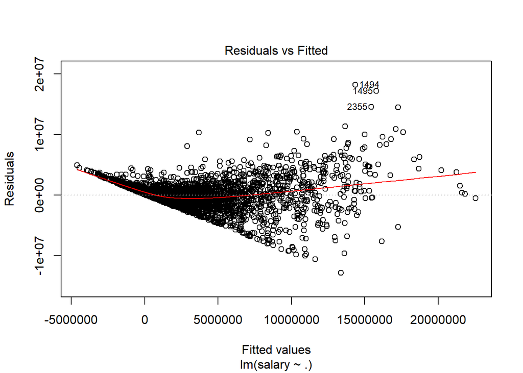

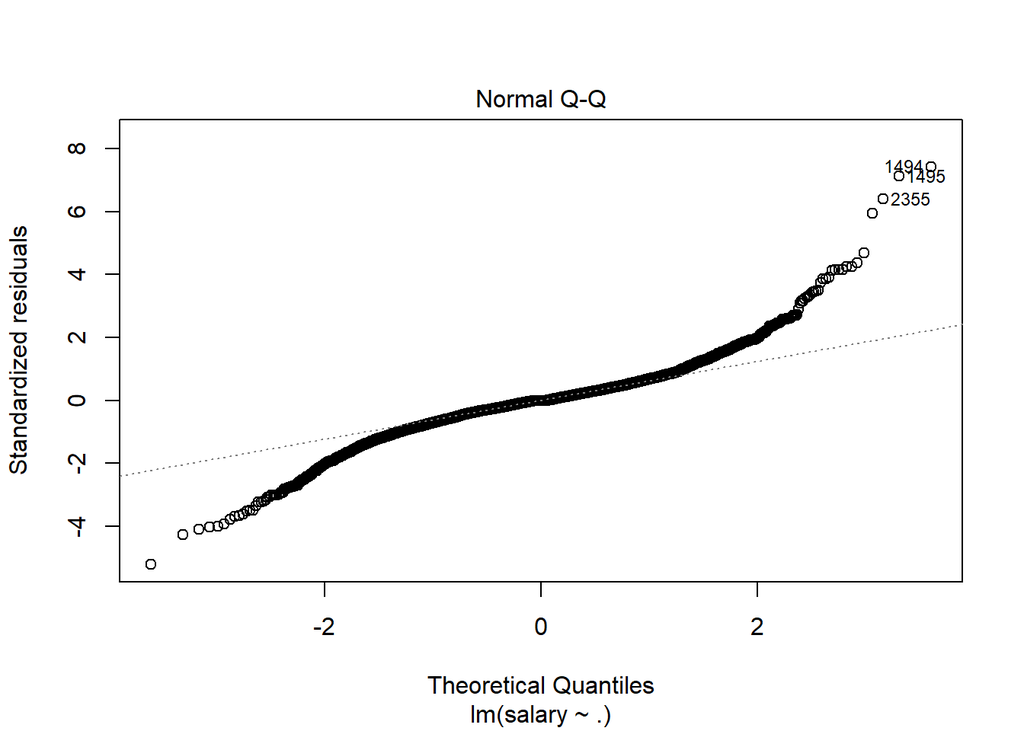

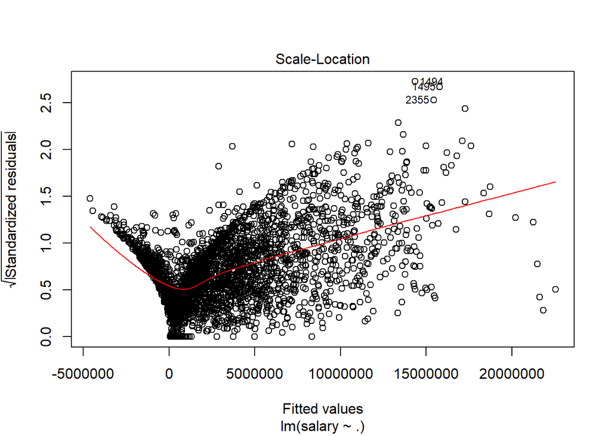

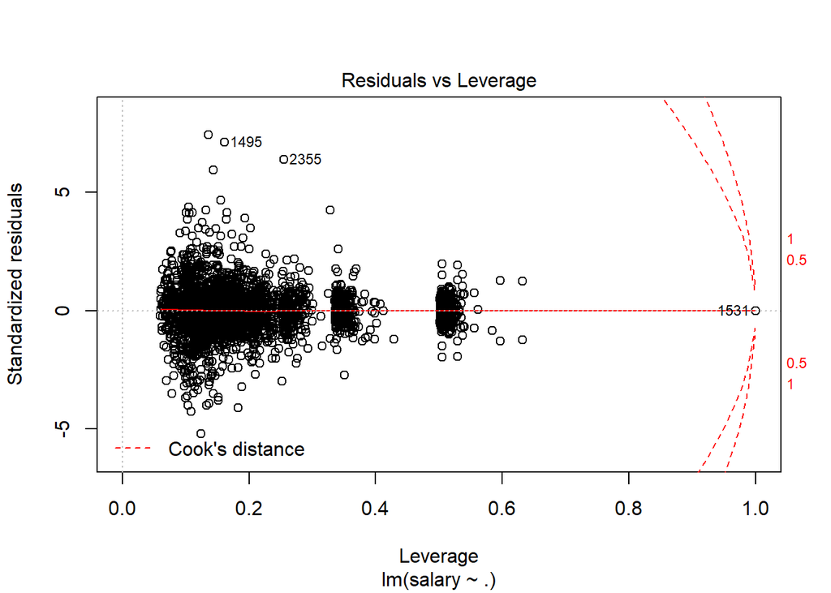

```r
plot(spmodel)
```

當我們建立出一個線性回歸時，必須要確認其殘差(residual)是否符合下面三個假設：

常態性(Normality)

獨立性(Independence)

變異數同質性(Homogeneity of Variance)

故首先我們要先從回歸模型中找到殘差的值，可以使用names()函式，查看回歸模型內具有的資訊

```r
str(spmodel)
```

[output not shown]

[output cut: 44 more lines]

[output not shown]

```r
names(spmodel)
```

```
##  [1] "coefficients"  "residuals"     "effects"       "rank"
##  [5] "fitted.values" "assign"        "qr"            "df.residual"
##  [9] "contrasts"     "xlevels"       "call"          "terms"
## [13] "model"
```

其中，residuals就是指殘差的值(coefficients代表係數)，因此我們可以取出來後進行上面三個假設的檢定： 常態性假設 shapiro.test()函式可以用來檢驗殘差的常態性：

```r
shapiro.test(spmodel$residual)
```

```
##
##  Shapiro-Wilk normality test
##
## data:  spmodel$residual
## W = 0.90469, p-value < 2.2e-16
```

虛無假設H0:殘差服從常態分配，因為p-value < 0.05，代表拒絕H0。

獨立性假設 要檢驗殘差的獨立性，需要使用套件car中的durbinWatsonTest()函式：

```r
# 因為這個函式會自動去抓模型中的殘差，故這裡放的是模型，而不是殘差的值
durbinWatsonTest(spmodel)
```

```
##  lag Autocorrelation D-W Statistic p-value
##    1       0.4060344      1.187153       0
##  Alternative hypothesis: rho != 0
```

虛無假設H0:殘差間相互獨立，因為p-value < 0.05，代表拒絕H0。

```r
# 因為這個函式會自動去抓模型中的殘差，故這裡放的是模型，而不是殘差的值
# ncvTest(spmodel)
```

#### pcr

```
## Data:    X dimension: 3321 27
##  Y dimension: 3321 1
## Fit method: svdpc
## Number of components considered: 27
##
## VALIDATION: RMSEP
## Cross-validated using 10 random segments.
##        (Intercept)  1 comps  2 comps  3 comps  4 comps  5 comps  6 comps
## CV         4439241  4417588  4399133  4333119  4314086  4200321  4165600
## adjCV      4439241  4417501  4398997  4332785  4313942  4199938  4165069
##        7 comps  8 comps  9 comps  10 comps  11 comps  12 comps  13 comps
## CV     4149008  4149652  4150345   4151642   4136397   4136051   4120933
## adjCV  4148409  4148987  4149801   4150922   4135657   4135260   4120078
##        14 comps  15 comps  16 comps  17 comps  18 comps  19 comps  20 comps
## CV      4122604   4108790   4083521   4084414   4044870   4023147   4022647
## adjCV   4121832   4108198   4082489   4083419   4043634   4021924   4021324
##        21 comps  22 comps  23 comps  24 comps  25 comps  26 comps  27 comps
## CV      4023132   4006969   3989916   3987640   3989797   3991607   3993265
## adjCV   4021819   4005194   3988428   3986064   3988112   3989822   3991392
##
## TRAINING: % variance explained
##         1 comps  2 comps  3 comps  4 comps  5 comps  6 comps  7 comps  8 comps
## X       28.0494    46.62   55.928   61.786    67.05    71.48    75.38    78.62
## salary   0.9964     1.87    4.894    5.728    10.72    12.29    12.99    13.01
##         9 comps  10 comps  11 comps  12 comps  13 comps  14 comps  15 comps
## X         81.72     84.75     87.27     89.51     91.54     93.07     94.48
## salary    13.01     13.04     13.67     13.75     14.46     14.46     15.09
##         16 comps  17 comps  18 comps  19 comps  20 comps  21 comps  22 comps
## X          95.73     96.80     97.70     98.50     99.00     99.36     99.58
## salary     16.16     16.17     17.88     18.74     18.86     18.86     19.61
##         23 comps  24 comps  25 comps  26 comps  27 comps
## X          99.77     99.89     99.96     99.99    100.00
## salary     20.32     20.46     20.46     20.47     20.47
```

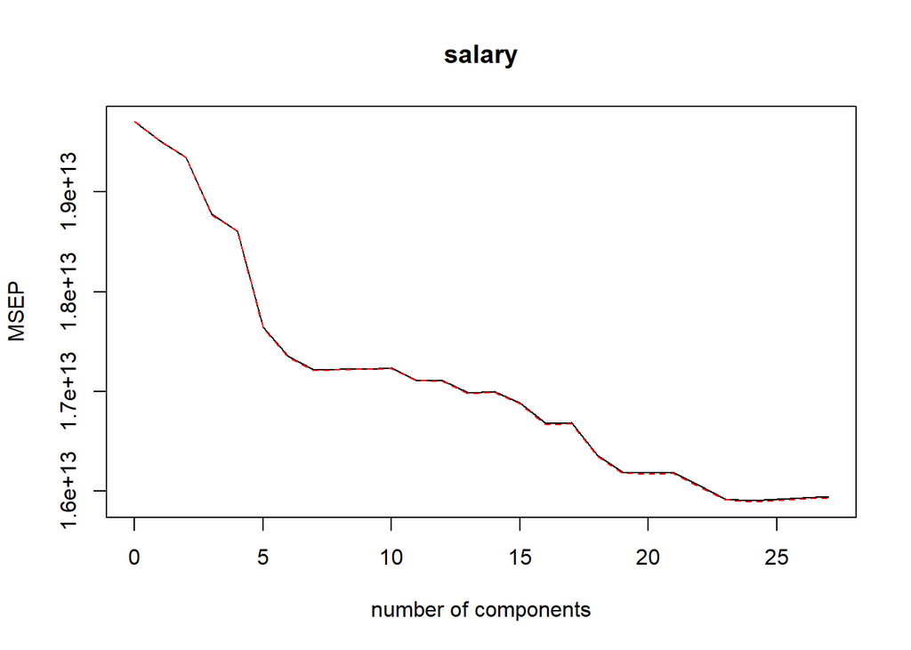

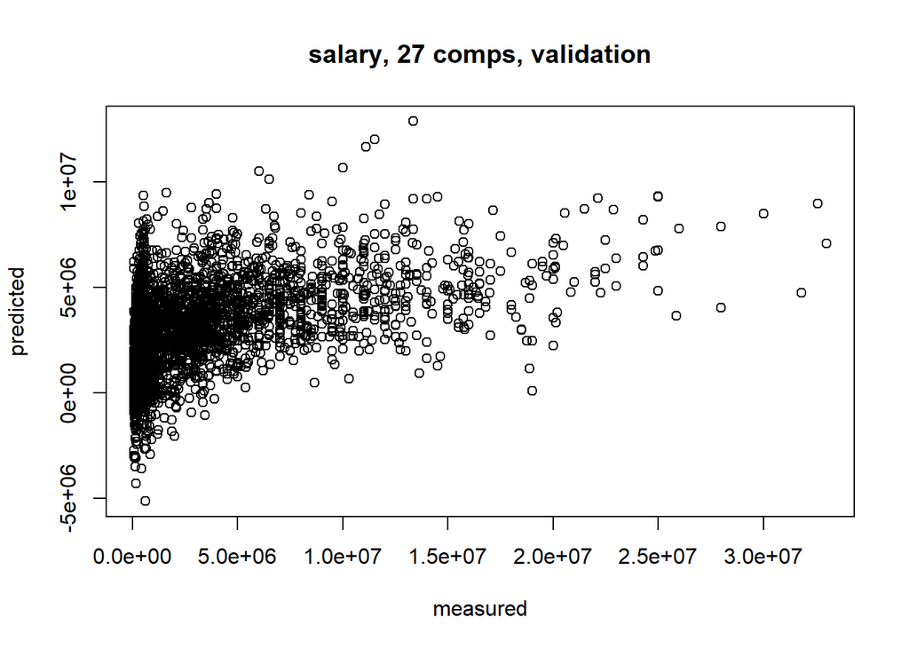

```
## , , 3 comps
##
##                  salary
## (Intercept) 4701215.500
## W             97763.683
## L            -73488.142
## G           -248693.410
## GS           131048.386
## CG            25755.418
## SHO           45968.780
## SV          -243331.954
## IPouts        54174.269
## H             -6893.546
## ER           -42916.606
## HR             7886.404
## BB           -26798.387
## SO            99511.331
## BAOpp        -90121.997
## IBB         -133614.707
## WP             1095.393
## HBP           27980.897
## BK           -29159.207
## BFP           36652.275
## GF          -271942.733
## R            -46842.965
## SH           -51242.651
## SF           -45763.772
## GIDP          -8716.115
## ERA_plus      91516.351
## APR           30367.216
## ERA          -81143.491
```

```
## , , 1 comps
##
##                 salary
## (Intercept) 838507.092
## W            36943.393
## L            23760.014
## G             5981.841
## GS           52817.898
## CG           32548.205
## SHO          23979.345
## SV          -17986.910
## IPouts       55263.771
## H            49658.255
## ER           36534.785
## HR           23251.759
## BB           27188.233
## SO           33393.638
## BAOpp        -7163.584
## IBB           6065.556
## WP           13371.687
## HBP          13120.111
## BK            6996.124
## BFP          56596.401
## GF          -26292.429
## R            38302.954
## SH           19581.163
## SF           18202.260
## GIDP         27369.971
## ERA_plus      8020.358
## APR          49745.740
## ERA         -10200.851
##
## , , 2 comps
##
##                  salary
## (Intercept) 2065377.792
## W             77750.310
## L            -21428.215
## G             13496.271
## GS            50040.819
```

[output cut: 40 more lines]

```
## SO            99511.331
## BAOpp        -90121.997
## IBB         -133614.707
## WP             1095.393
## HBP           27980.897
## BK           -29159.207
## BFP           36652.275
## GF          -271942.733
## R            -46842.965
## SH           -51242.651
## SF           -45763.772
## GIDP          -8716.115
## ERA_plus      91516.351
## APR           30367.216
## ERA          -81143.491
```

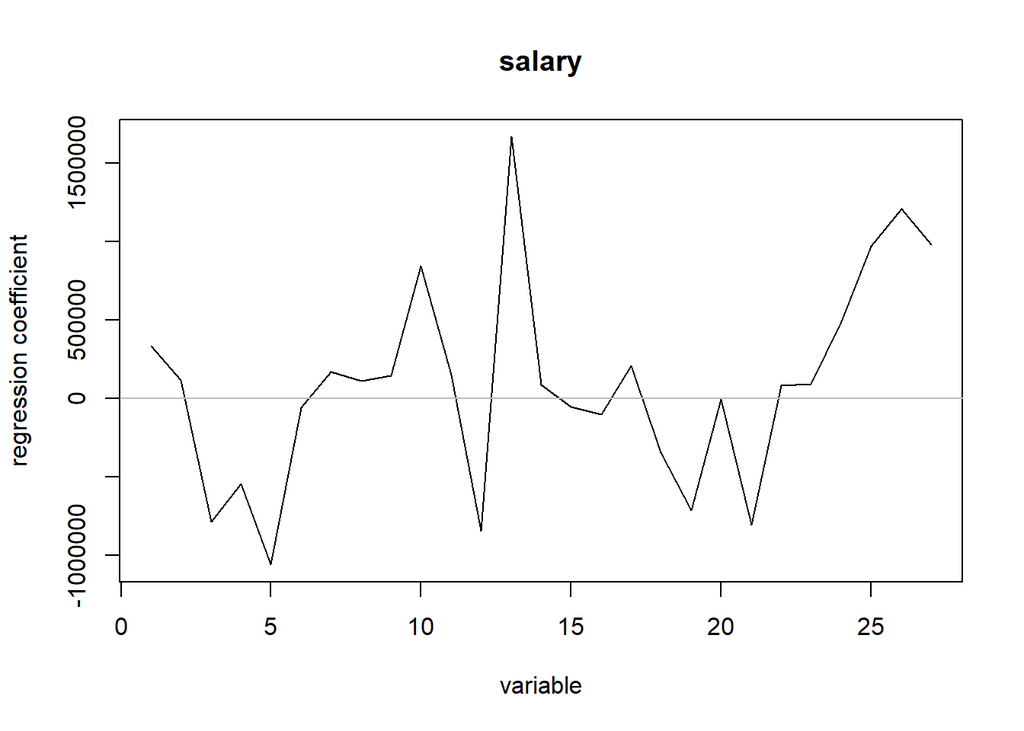

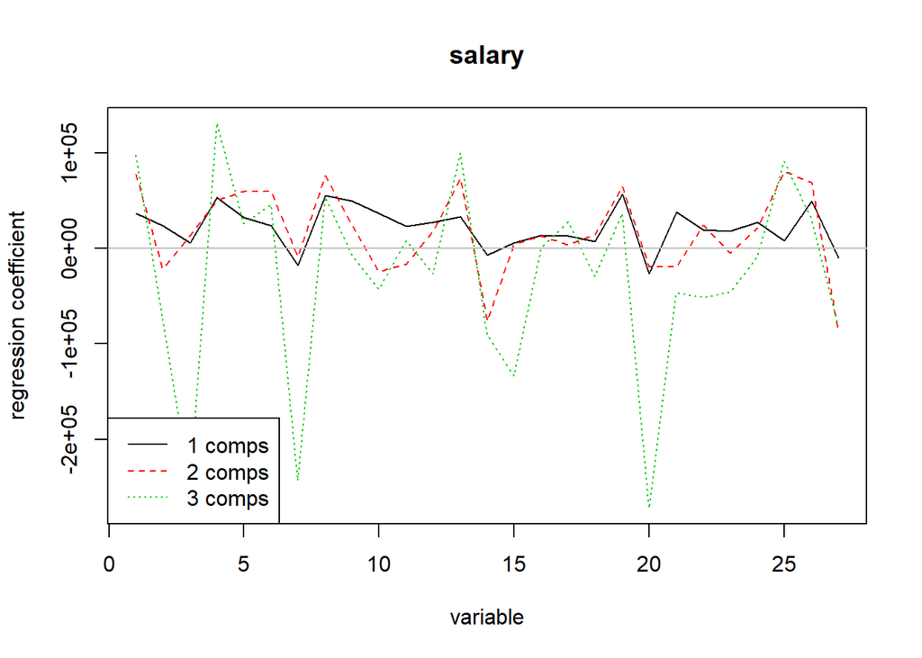

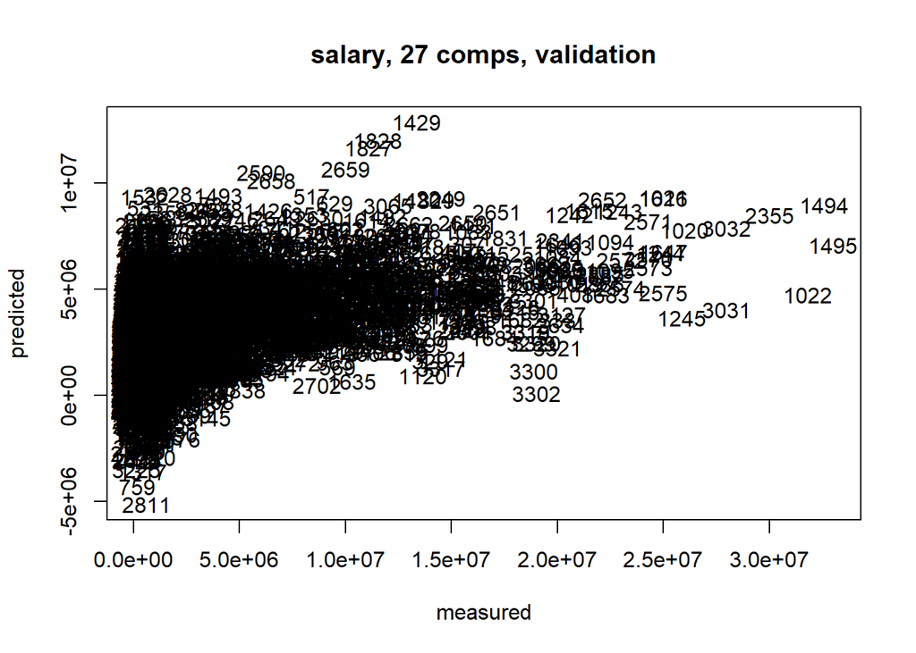

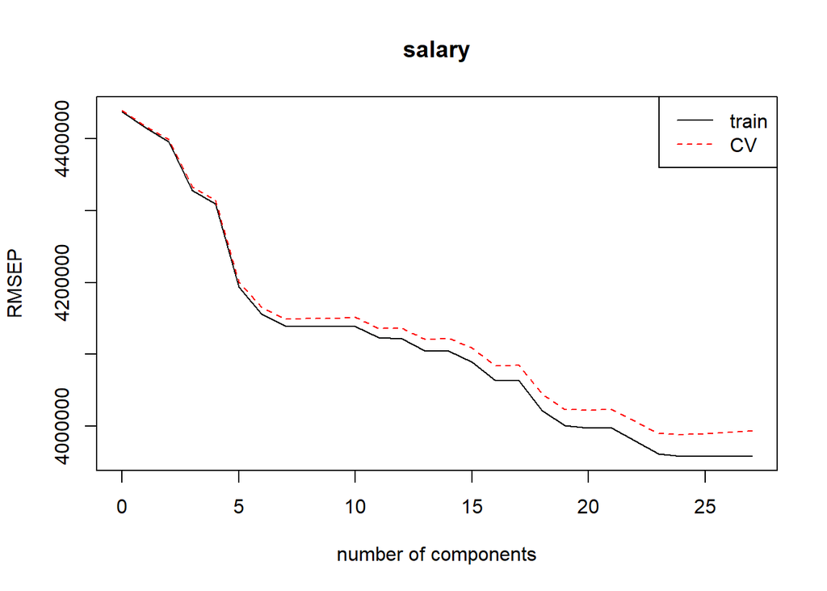

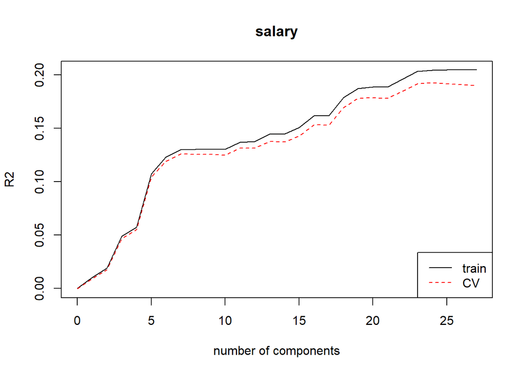

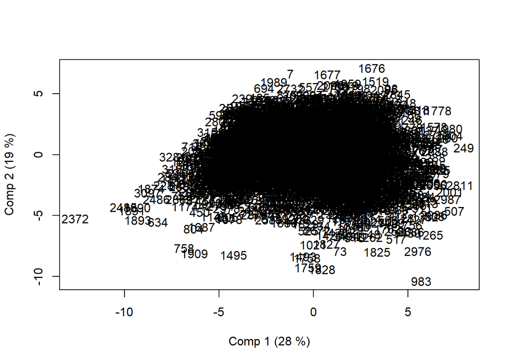

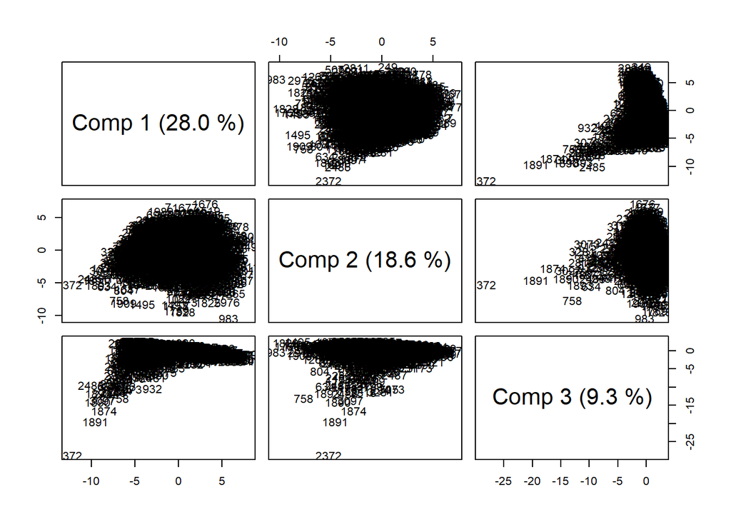

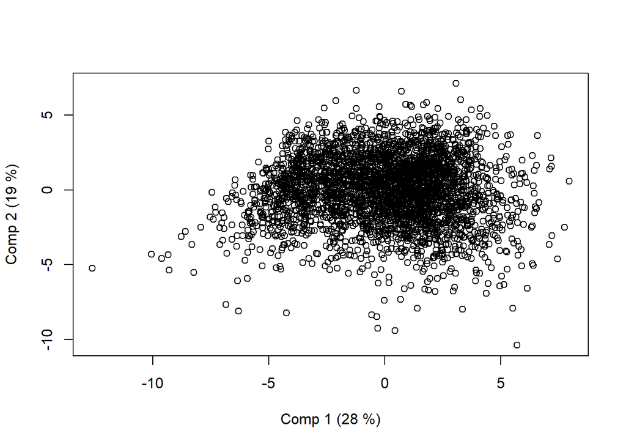

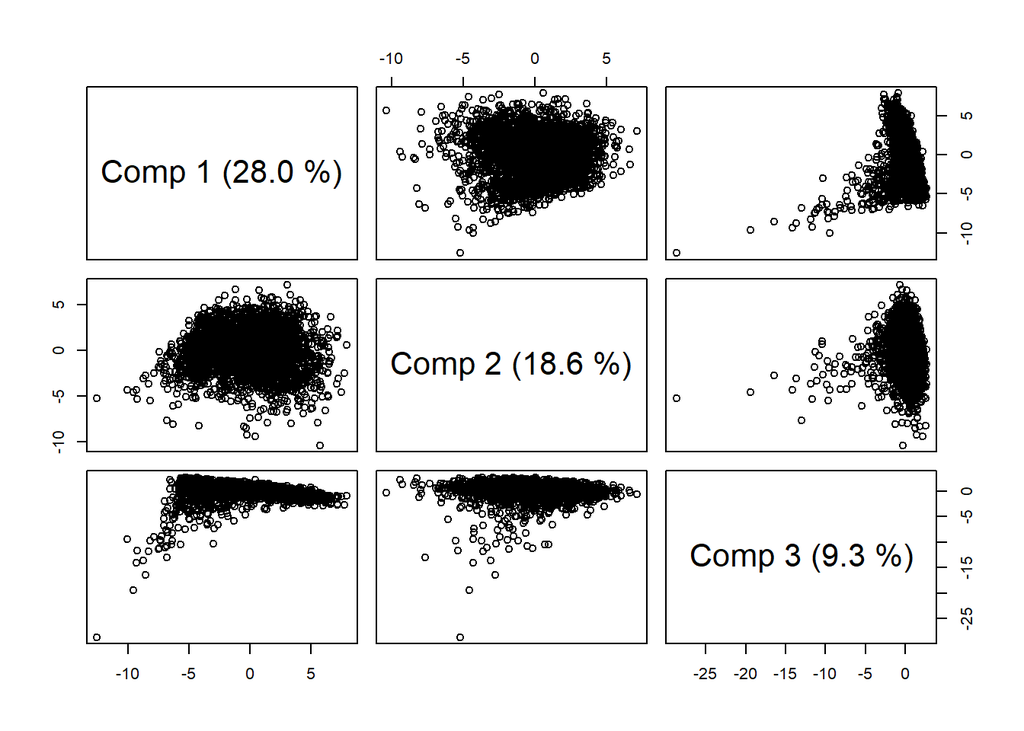

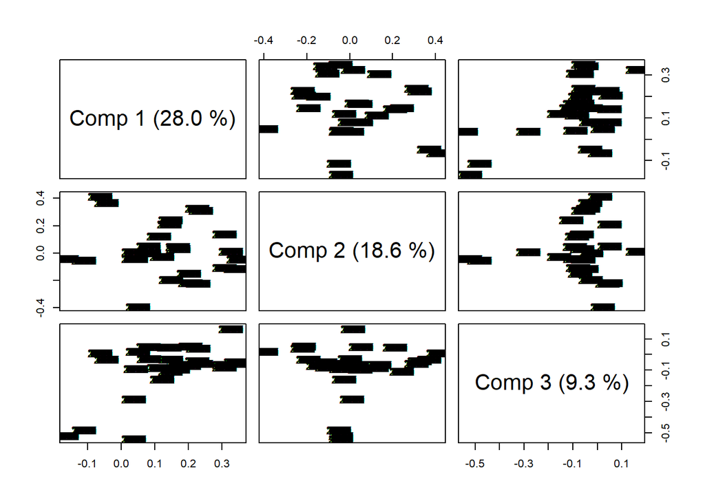

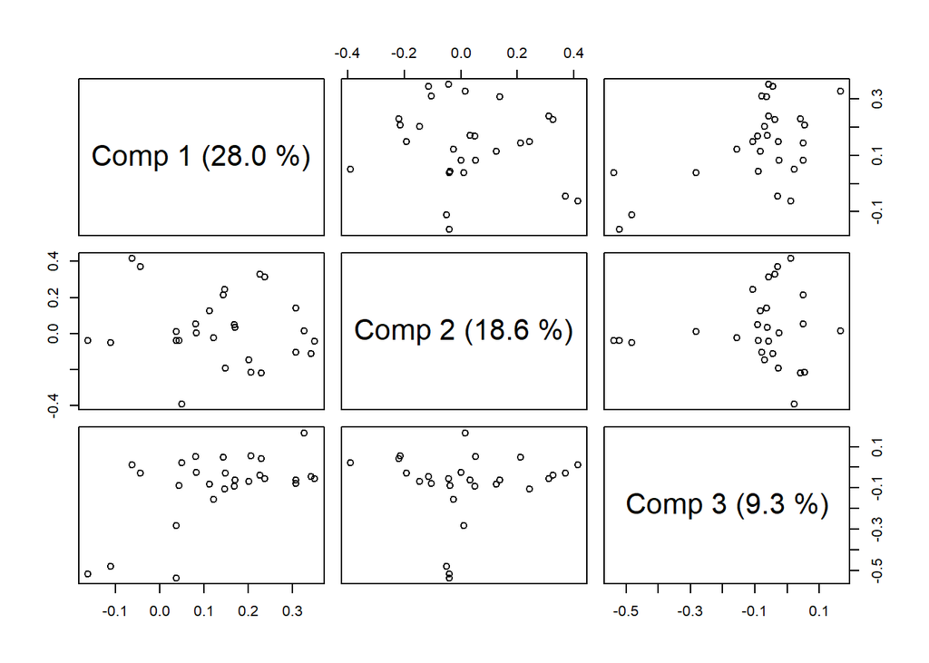

```
## Data:    X dimension: 2327 27
##  Y dimension: 2327 1
## Fit method: svdpc
## Number of components considered: 27
##
## VALIDATION: RMSEP
## Cross-validated using 10 random segments.
##        (Intercept)  1 comps  2 comps  3 comps  4 comps  5 comps  6 comps
## CV         4400453  4369003  4290096  4276572  4169149  4121826  4123763
## adjCV      4400453  4368865  4289732  4275973  4168949  4121113  4122703
##        7 comps  8 comps  9 comps  10 comps  11 comps  12 comps  13 comps
## CV     4124176  4096316  4080901   4055260   4054678   4033188   4035041
## adjCV  4123019  4095041  4079485   4053881   4053201   4031680   4033399
##        14 comps  15 comps  16 comps  17 comps  18 comps  19 comps  20 comps
## CV      4035341   4033436   4020758   4021249   4017930   4010845   4004345
## adjCV   4033508   4031841   4018731   4019231   4015838   4008500   4002211
##        21 comps  22 comps  23 comps  24 comps  25 comps  26 comps  27 comps
## CV      3992262   3990701   3991967   3990555   3987570   3982661   3984784
## adjCV   3989920   3988191   3989724   3987944   3984771   3979865   3981862
##
## TRAINING: % variance explained
##         1 comps  2 comps  3 comps  4 comps  5 comps  6 comps  7 comps  8 comps
## X        88.767   94.988   97.205    98.29    99.03    99.37    99.54    99.68
## salary    1.457    5.187    5.971    10.57    12.75    12.94    13.07    14.28
##         9 comps  10 comps  11 comps  12 comps  13 comps  14 comps  15 comps
## X         99.74     99.79     99.83     99.86     99.89     99.91     99.93
## salary    15.02     16.07     16.15     17.10     17.12     17.27     17.38
##         16 comps  17 comps  18 comps  19 comps  20 comps  21 comps  22 comps
## X          99.94     99.96     99.97     99.98     99.99     99.99    100.00
## salary     17.96     17.99     18.16     18.50     18.85     19.50     19.62
##         23 comps  24 comps  25 comps  26 comps  27 comps
## X         100.00     100.0    100.00    100.00    100.00
## salary     19.62      19.7     19.95     20.15     20.16
```

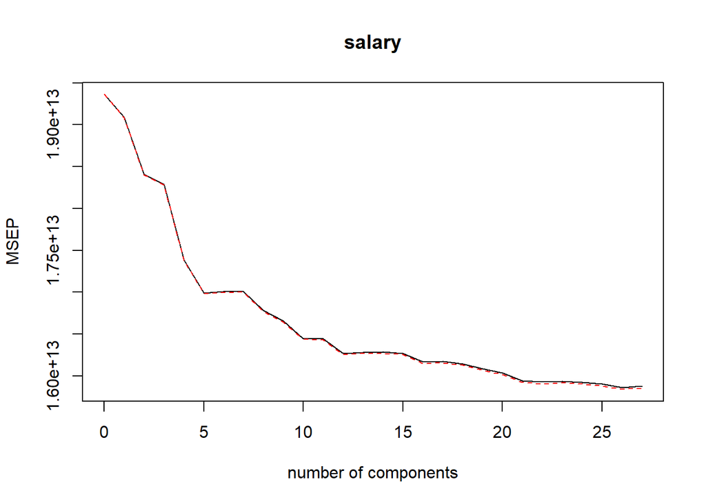

```
## Data:    X dimension: 2327 27
##  Y dimension: 2327 1
## Fit method: svdpc
## Number of components considered: 27
##
## VALIDATION: RMSEP
## Cross-validated using 10 random segments.
##        (Intercept)  1 comps  2 comps  3 comps  4 comps  5 comps  6 comps
## CV         4400453  4376291  4360601  4299511  4275721  4166665  4122661
## adjCV      4400453  4376218  4360414  4298911  4275441  4166169  4121956
##        7 comps  8 comps  9 comps  10 comps  11 comps  12 comps  13 comps
## CV     4116605  4117910  4118400   4120929   4108857   4108394   4100298
## adjCV  4115829  4117124  4117536   4120004   4107804   4107693   4099103
##        14 comps  15 comps  16 comps  17 comps  18 comps  19 comps  20 comps
## CV      4100668   4083249   4060247   4060058   4018176   3998911   3998487
## adjCV   4099740   4082211   4058806   4058712   4016434   3997244   3996658
##        21 comps  22 comps  23 comps  24 comps  25 comps  26 comps  27 comps
## CV      4000518   3991123   3969660   3973476   3974963   3976042   3978056
## adjCV   3998678   3987164   3967664   3971194   3972594   3973599   3975486
##
## TRAINING: % variance explained
##         1 comps  2 comps  3 comps  4 comps  5 comps  6 comps  7 comps  8 comps
## X        27.974   46.553   55.888   61.611    66.95    71.36    75.19    78.51
## salary    1.086    1.902    4.877    5.936    10.68    12.61    12.90    12.92
##         9 comps  10 comps  11 comps  12 comps  13 comps  14 comps  15 comps
## X         81.57     84.57     87.13     89.41     91.53     93.08     94.52
## salary    12.93     12.93     13.54     13.56     14.01     14.01     14.75
##         16 comps  17 comps  18 comps  19 comps  20 comps  21 comps  22 comps
## X          95.77     96.81     97.71     98.52     99.02     99.37     99.59
## salary     15.92     15.94     17.79     18.60     18.78     18.79     19.48
##         23 comps  24 comps  25 comps  26 comps  27 comps
## X          99.77     99.89     99.96     99.99    100.00
## salary     20.11     20.14     20.14     20.15     20.16
```

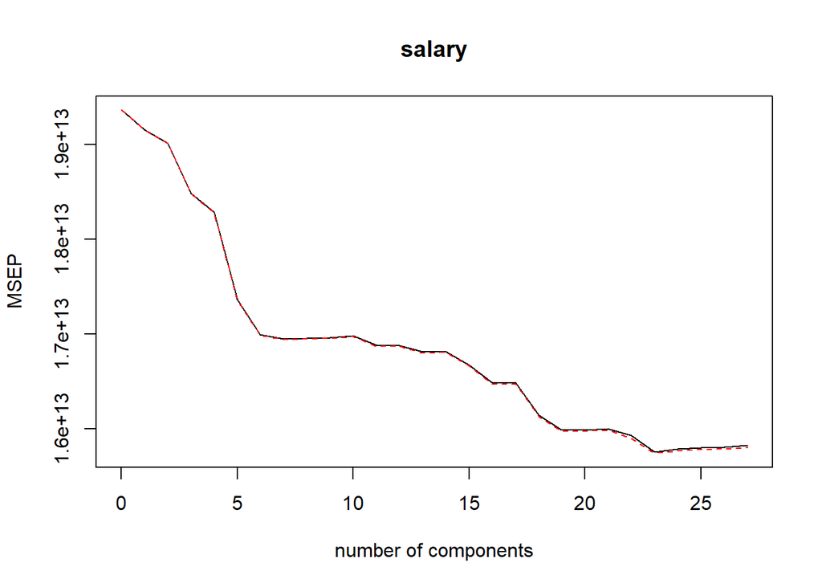